# Political Science Academic Job Market

- Show All Code
- Hide All Code
- View Source

An NLP Analysis of APSA eJobs Listings

Author

Knowledge Mining Workshop

Published

April 9, 2026

# Executive Summary

This report analyzes the political science academic job market using all active listings published in **APSA *Political Science Jobs*** — the official monthly eJobs journal of the American Political Science Association. Subfield counts are sourced directly from each issue’s **Table of Contents** (page 2) for accuracy, while individual job records are scraped from body text and verified against those ground-truth counts.

## 0.1 Dataset at a Glance

113

Issues Processed

10,168

Unique Job Listings

5,576

Unique Institutions

2016–2026

Years Covered

## 0.2 Geographic Overview

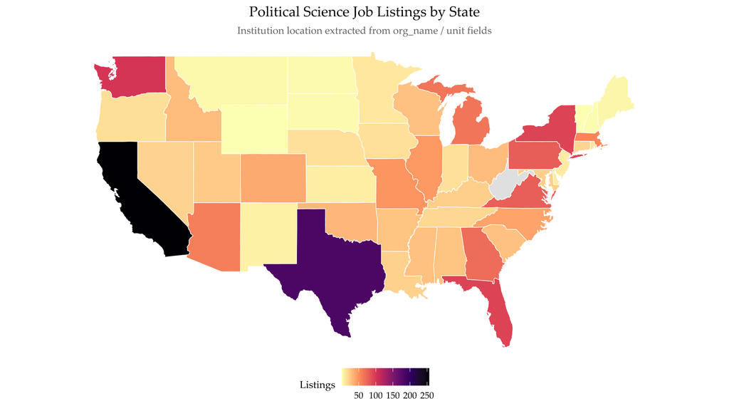

# 1 Data Collection & Parsing

## 1.1 Methodology

The data pipeline operates in three stages:

1. **PDF Extraction** — `pdftools::pdf_text()` reads raw text from each monthly issue.
2. **Page 2 TOC Parsing** — A regex pipeline targeting `(N listings)` on the Table of Contents extracts the **official, ground-truth count** per subfield per issue.
3. **Body Text Scraping** — The parser walks the document line-by-line, tracking section headers to assign subfields, flushing a record each time it detects an `eJobs ID:` marker.

## 1.2 Verification Report

| source_file | subfield | toc_count | scraped_count | diff | status |
| --- | --- | --- | --- | --- | --- |
| PSJobs201710.pdf | Other | 55 | 270 | 215 | OVER |
| PSJobs202109.pdf | PT | 16 | 209 | 193 | OVER |
| PSJobs202309.pdf | PL | 23 | 215 | 192 | OVER |
| PSJobs202511.pdf | PL | 25 | 180 | 155 | OVER |
| PSJobs201810.pdf | CP | 115 | 259 | 144 | OVER |
| PSJobs202412.pdf | Non-Academic | 2 | 140 | 138 | OVER |
| PSJobs202011.pdf | Open | 29 | 165 | 136 | OVER |
| PSJobs201802.pdf | Admin | 14 | 135 | 121 | OVER |
| PSJobs201808.pdf | PT | 18 | 138 | 120 | OVER |
| PSJobs202405.pdf | Admin | 3 | 122 | 119 | OVER |

[output cut: 1036 more lines]

# 2 Subfield Analysis

## 2.1 Summary Statistics by Subfield

Summary Statistics by Subfield

| Subfield | N Jobs | N w/ Salary | Median Salary | Mean Salary | % TT | % Visiting | % Teaching Trk | % Postdoc |
| --- | --- | --- | --- | --- | --- | --- | --- | --- |
| Methods | 1496 | 191 | $65,000 | $72,254 | 15.4% | 3.9% | 4.3% | 6.5% |
| CP | 1490 | 172 | $65,000 | $67,282 | 16.4% | 2.9% | 3.0% | 7.0% |
| IR | 1461 | 179 | $60,000 | $66,753 | 14.6% | 2.7% | 3.1% | 8.5% |
| AP | 946 | 105 | $65,000 | $68,731 | 16.4% | 4.2% | 5.5% | 9.6% |
| Other | 946 | 94 | $65,000 | $67,877 | 16.1% | 3.1% | 3.7% | 6.0% |
| PT | 942 | 78 | $65,000 | $64,371 | 16.2% | 3.8% | 3.9% | 5.1% |
| PL | 634 | 60 | $75,000 | $74,696 | 23.0% | 4.1% | 2.8% | 4.1% |
| PP | 574 | 61 | $72,500 | $78,408 | 15.9% | 2.4% | 3.5% | 7.1% |
| Open | 525 | 64 | $65,000 | $73,694 | 12.6% | 1.5% | 4.2% | 7.4% |
| Non-Academic | 501 | 54 | $65,000 | $72,906 | 12.4% | 2.2% | 3.4% | 4.6% |
| Admin | 494 | 55 | $65,000 | $76,880 | 14.4% | 3.6% | 4.0% | 3.8% |
| PAdmin | 159 | 15 | $65,000 | $67,880 | 17.6% | 1.3% | 5.0% | 1.3% |

## 2.2 Trends Over Time

**By Subfield**

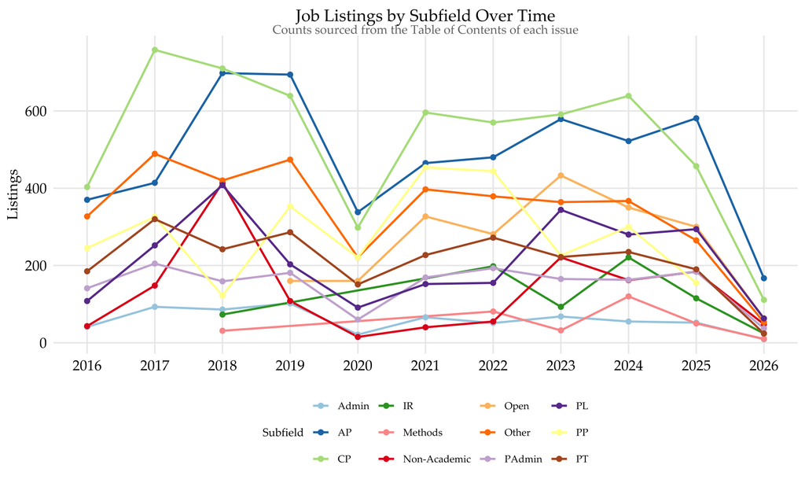

```r
toc_year %>%
  filter(!is.na(year), !is.na(subfield)) %>%
  ggplot(aes(x = year, y = toc_count, colour = subfield)) +
  geom_line(linewidth = 0.9) +
  geom_point(size = 1.8) +
  scale_colour_brewer(palette = "Paired") +
  scale_x_continuous(breaks = pretty_breaks(n = 8)) +
  labs(title    = "Job Listings by Subfield Over Time",
       subtitle = "Counts sourced from the Table of Contents of each issue",
       x = NULL, y = "Listings", colour = "Subfield") +
  theme(legend.position = "bottom",
        legend.text = element_text(size = 9, family = PAL))
```

**Annual Total**

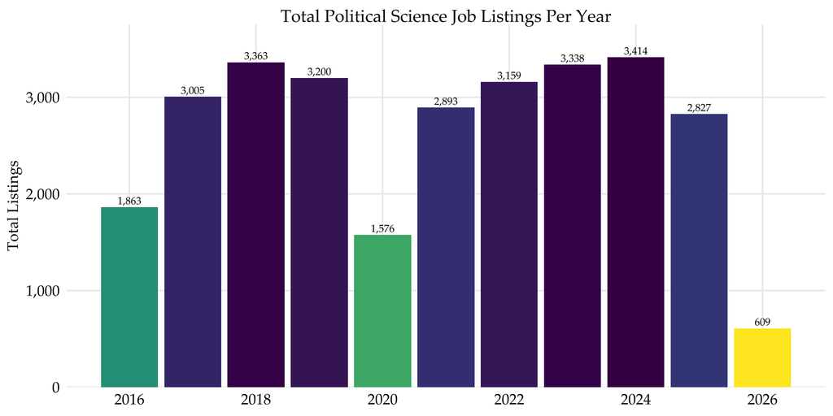

```r
annual_totals %>%
  filter(!is.na(year)) %>%
  ggplot(aes(x = year, y = total, fill = total)) +
  geom_col(show.legend = FALSE) +
  geom_text(aes(label = comma(total)), vjust = -0.4,
            size = 3.2, family = PAL) +
  scale_fill_viridis_c(option = "D", direction = -1) +
  scale_x_continuous(breaks = pretty_breaks(n = 8)) +
  scale_y_continuous(labels = comma, expand = expansion(mult = c(0, .1))) +
  labs(title = "Total Political Science Job Listings Per Year",
       x = NULL, y = "Total Listings")
```

**Heatmap**

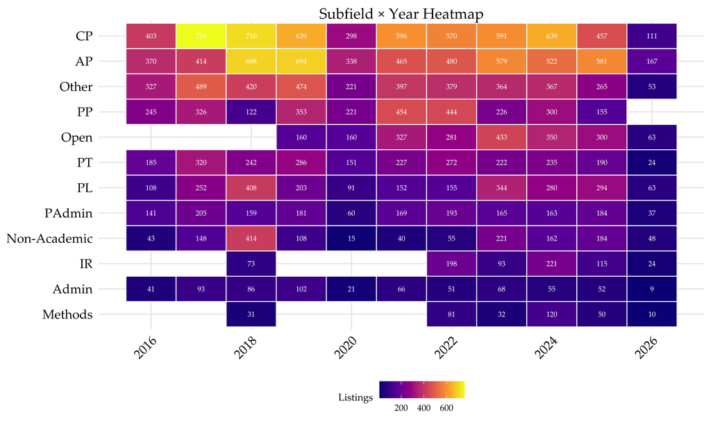

```r
toc_year %>%
  filter(!is.na(year), !is.na(subfield)) %>%
  ggplot(aes(x = year,
             y = reorder(subfield, toc_count),
             fill = toc_count)) +
  geom_tile(colour = "white", linewidth = 0.4) +
  geom_text(aes(label = toc_count), size = 2.6,
            colour = "white", family = PAL) +
  scale_fill_viridis_c(option = "C", name = "Listings") +
  scale_x_continuous(breaks = pretty_breaks(n = 8)) +
  labs(title = "Subfield × Year Heatmap", x = NULL, y = NULL) +
  theme(axis.text.x = element_text(angle = 45, hjust = 1, family = PAL),
        legend.position = "bottom",
        legend.text = element_text(size = 9, family = PAL))
```

# 3 Rank Analysis

## 3.1 Distribution of Rank Categories

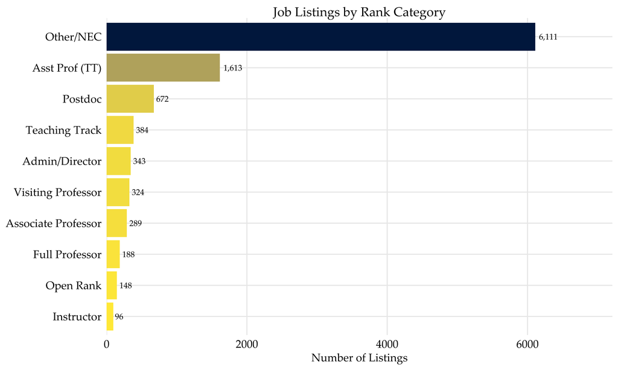

```r
rank_order <- jobs %>%
  count(rank_category) %>% arrange(n) %>% pull(rank_category)

jobs %>%
  count(rank_category) %>%
  mutate(rank_category = factor(rank_category, levels = rank_order)) %>%
  ggplot(aes(x = n, y = rank_category, fill = n)) +
  geom_col(show.legend = FALSE) +
  geom_text(aes(label = comma(n)), hjust = -0.2,
            size = 3.4, family = PAL) +
  scale_fill_viridis_c(option = "E", direction = -1) +
  scale_x_continuous(expand = expansion(mult = c(0, .18))) +
  labs(title = "Job Listings by Rank Category",
       x = "Number of Listings", y = NULL)
```

## 3.2 Rank Composition by Subfield

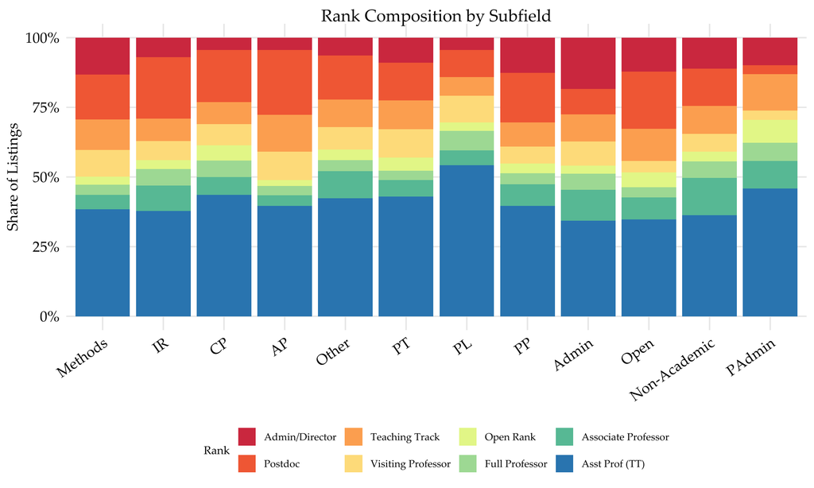

```r
jobs %>%
  filter(rank_category %in% tt_ranks, !is.na(subfield)) %>%
  count(subfield, rank_category) %>%
  group_by(subfield) %>%
  mutate(pct = n / sum(n)) %>% ungroup() %>%
  ggplot(aes(x = reorder(subfield, -n, sum), y = pct,
             fill = factor(rank_category, levels = rev(tt_ranks)))) +
  geom_col() +
  scale_y_continuous(labels = percent_format()) +
  scale_fill_brewer(palette = "Spectral", name = "Rank") +
  labs(title = "Rank Composition by Subfield",
       x = NULL, y = "Share of Listings") +
  theme(axis.text.x = element_text(angle = 35, hjust = 1, family = PAL),
        legend.position = "bottom",
        legend.text = element_text(size = 9, family = PAL))
```

## 3.3 Rank Trends Over Time

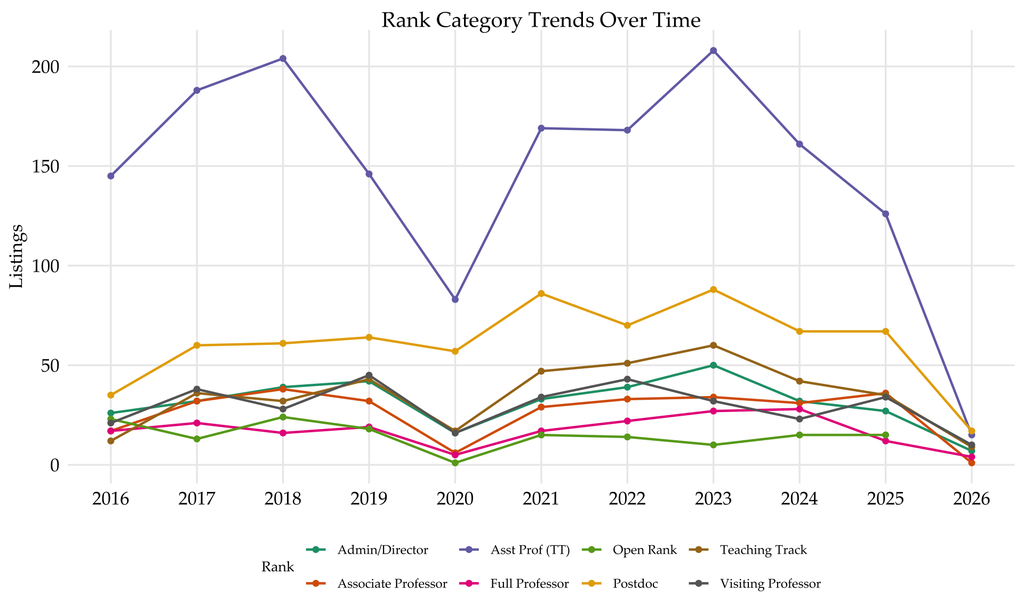

```r
jobs %>%
  filter(rank_category %in% tt_ranks, !is.na(year)) %>%
  count(year, rank_category) %>%
  ggplot(aes(x = year, y = n, colour = rank_category)) +
  geom_line(linewidth = 0.8) +
  geom_point(size = 1.5) +
  scale_colour_brewer(palette = "Dark2", name = "Rank") +
  scale_x_continuous(breaks = pretty_breaks(n = 8)) +
  labs(title = "Rank Category Trends Over Time",
       x = NULL, y = "Listings") +
  theme(legend.position = "bottom",
        legend.text = element_text(size = 9, family = PAL))
```

**Tip**

**Key observation:** Tenure-track assistant professor positions (`Asst Prof (TT)`) typically dominate the market. Watch the **Visiting Professor** and **Teaching Track** trend lines — a rising share may signal structural shifts in how departments staff their courses.

# 4 Geographic Distribution

## 4.1 Listings by US Region

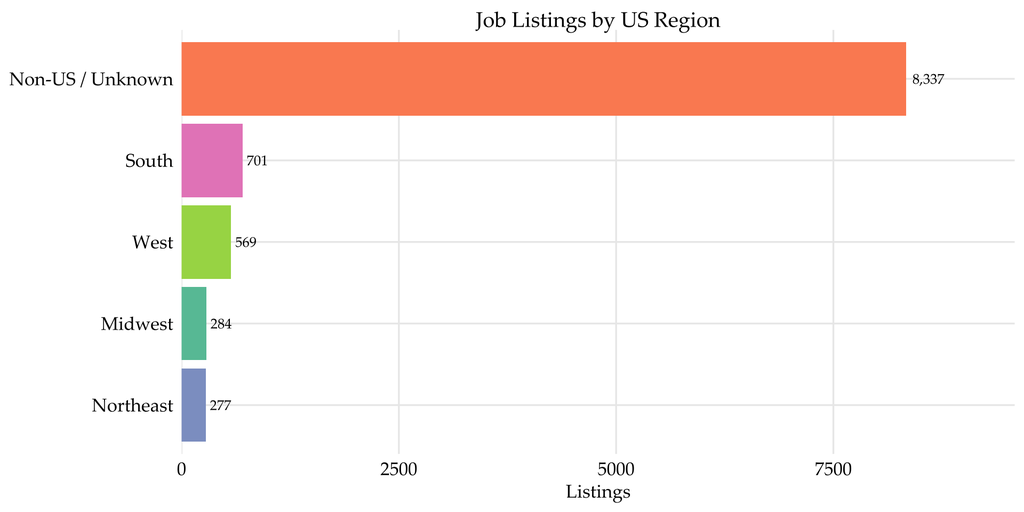

```r
jobs %>%
  count(region) %>%
  arrange(desc(n)) %>%
  ggplot(aes(x = reorder(region, n), y = n, fill = region)) +
  geom_col(show.legend = FALSE) +
  geom_text(aes(label = comma(n)), hjust = -0.2,
            size = 3.5, family = PAL) +
  scale_fill_brewer(palette = "Set2") +
  scale_y_continuous(expand = expansion(mult = c(0, .15))) +
  coord_flip() +
  labs(title = "Job Listings by US Region",
       x = NULL, y = "Listings")
```

## 4.2 Top 20 States

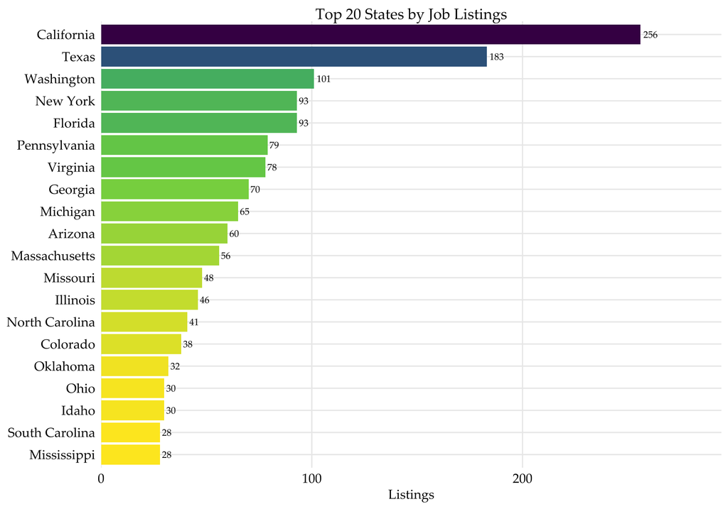

```r
jobs %>%
  filter(!is.na(state_raw)) %>%
  count(state_raw, sort = TRUE) %>%
  slice_head(n = 20) %>%
  ggplot(aes(x = n, y = reorder(state_raw, n), fill = n)) +
  geom_col(show.legend = FALSE) +
  geom_text(aes(label = comma(n)), hjust = -0.2,
            size = 3.3, family = PAL) +
  scale_fill_viridis_c(option = "D", direction = -1) +
  scale_x_continuous(expand = expansion(mult = c(0, .15))) +
  labs(title = "Top 20 States by Job Listings",
       x = "Listings", y = NULL)
```

## 4.3 State Choropleth (Detail)

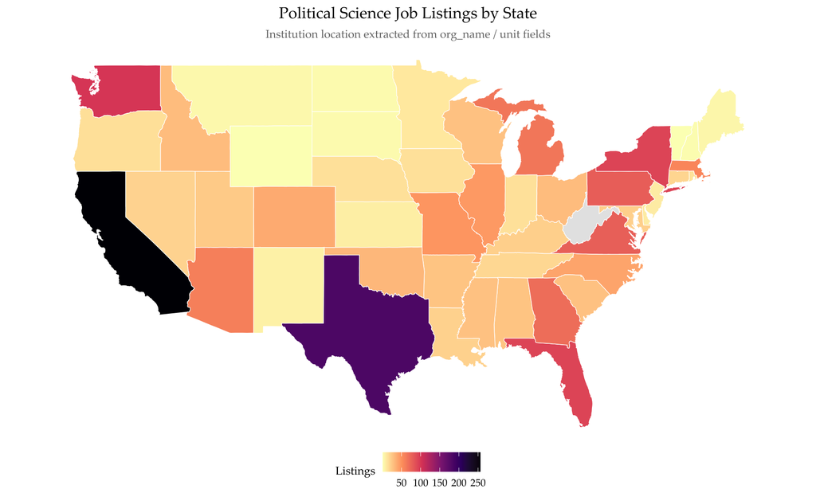

# 5 Salary Analysis

**Warning**

Only listings with an **explicit numeric salary** are included here. Most listings say “Competitive” or “Commensurate with experience” and are excluded. Interpret figures with caution.

## 5.1 Salary by Rank and Subfield

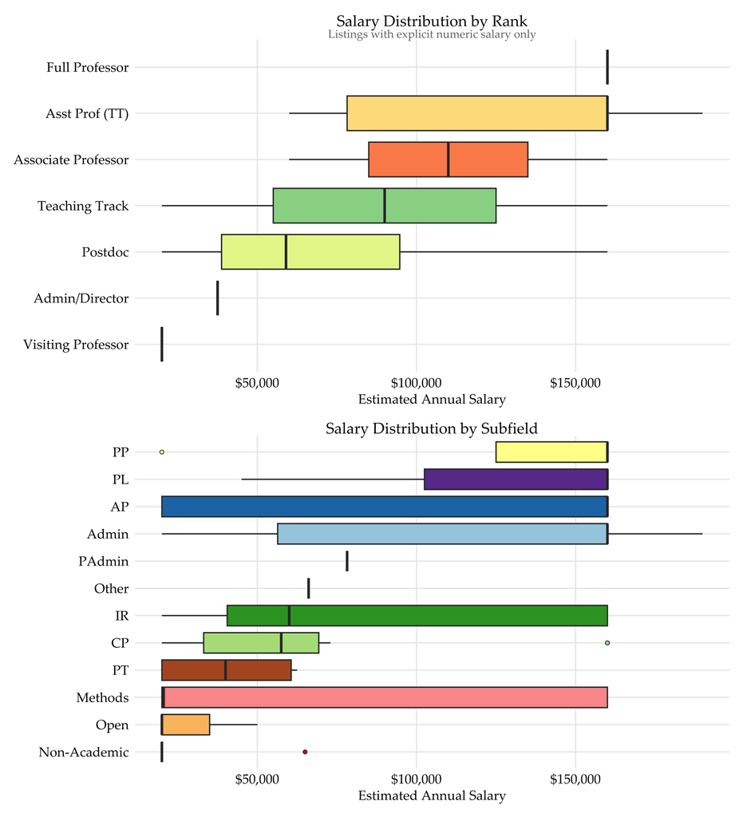

```r
sal_df <- jobs %>% filter(!is.na(salary_est), salary_est > 10000)

p_sal_rank <- sal_df %>%
  filter(rank_category %in% tt_ranks) %>%
  ggplot(aes(x = reorder(rank_category, salary_est, median),
             y = salary_est, fill = rank_category)) +
  geom_boxplot(outlier.shape = 21, outlier.size = 1.5, show.legend = FALSE) +
  scale_y_continuous(labels = dollar_format()) +
  scale_fill_brewer(palette = "Spectral") +
  coord_flip() +
  labs(title = "Salary Distribution by Rank",
       subtitle = "Listings with explicit numeric salary only",
       x = NULL, y = "Estimated Annual Salary")

p_sal_sf <- sal_df %>%
  filter(!is.na(subfield)) %>%
  ggplot(aes(x = reorder(subfield, salary_est, median),
             y = salary_est, fill = subfield)) +
  geom_boxplot(outlier.shape = 21, outlier.size = 1.5, show.legend = FALSE) +
  scale_y_continuous(labels = dollar_format()) +
  scale_fill_brewer(palette = "Paired") +
  coord_flip() +
  labs(title = "Salary Distribution by Subfield",
       x = NULL, y = "Estimated Annual Salary")

p_sal_rank / p_sal_sf
```

## 5.2 Salary Trend Over Time

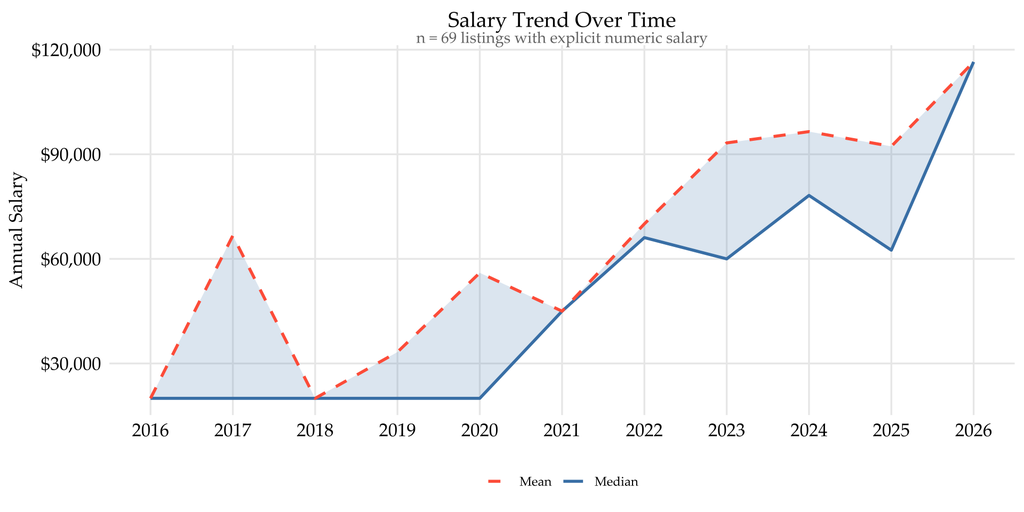

```r
sal_df %>%
  filter(!is.na(year)) %>%
  group_by(year) %>%
  summarise(median_sal = median(salary_est),
            mean_sal   = mean(salary_est),
            n = n(), .groups = "drop") %>%
  ggplot(aes(x = year)) +
  geom_ribbon(aes(ymin = median_sal, ymax = mean_sal),
              alpha = 0.18, fill = "steelblue") +
  geom_line(aes(y = median_sal, colour = "Median"), linewidth = 1) +
  geom_line(aes(y = mean_sal,   colour = "Mean"),
            linewidth = 1, linetype = "dashed") +
  scale_y_continuous(labels = dollar_format()) +
  scale_x_continuous(breaks = pretty_breaks(n = 8)) +
  scale_colour_manual(values = c(Median = "steelblue", Mean = "tomato"),
                      name = NULL) +
  labs(title    = "Salary Trend Over Time",
       subtitle = paste0("n = ", comma(nrow(sal_df)),
                         " listings with explicit numeric salary"),
       x = NULL, y = "Annual Salary") +
  theme(legend.position = "bottom",
        legend.text = element_text(size = 9, family = PAL))
```

# 6 Text Mining

## 6.1 Top 30 Terms

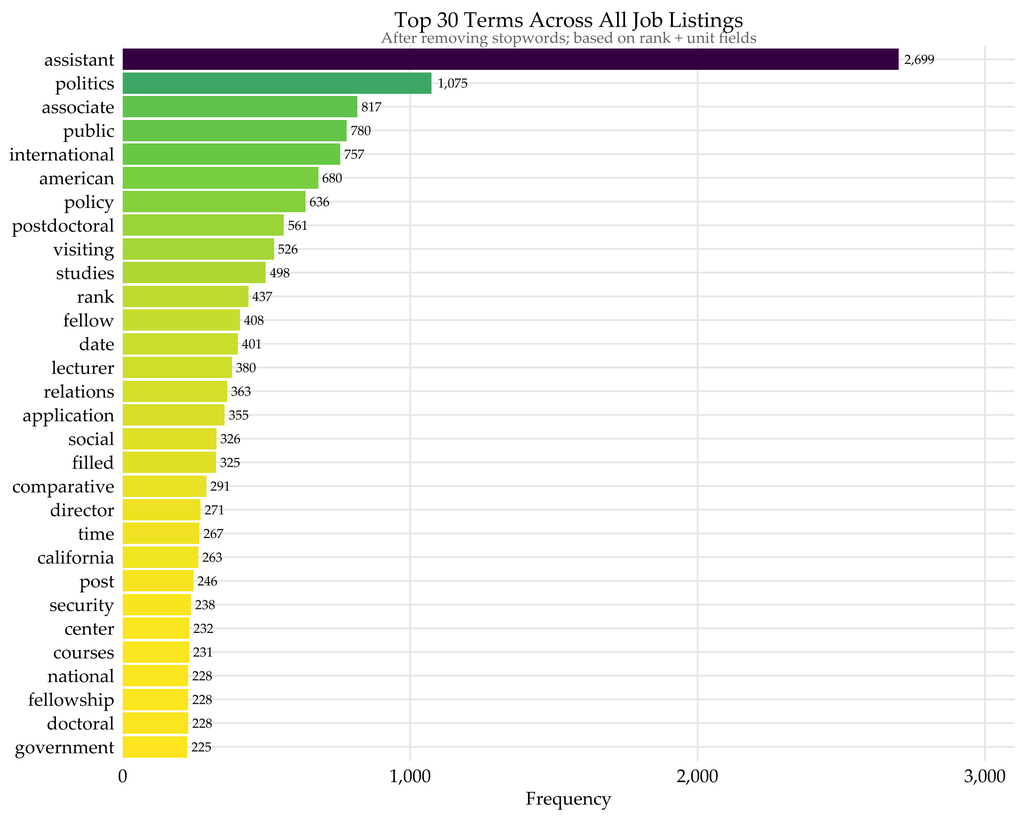

```r
tidy_words %>%
  count(word, sort = TRUE) %>%
  slice_head(n = 30) %>%
  ggplot(aes(x = n, y = reorder(word, n), fill = n)) +
  geom_col(show.legend = FALSE) +
  geom_text(aes(label = comma(n)), hjust = -0.2,
            size = 3.3, family = PAL) +
  scale_fill_viridis_c(option = "D", direction = -1) +
  scale_x_continuous(labels = comma,
                     expand = expansion(mult = c(0, .15))) +
  labs(title    = "Top 30 Terms Across All Job Listings",
       subtitle = "After removing stopwords; based on rank + unit fields",
       x = "Frequency", y = NULL)
```

## 6.2 TF-IDF: Distinctive Terms by Subfield

> **TF-IDF** (Term Frequency–Inverse Document Frequency) surfaces words that are *unusually common* in one subfield relative to all others — revealing the distinctive vocabulary of each field.

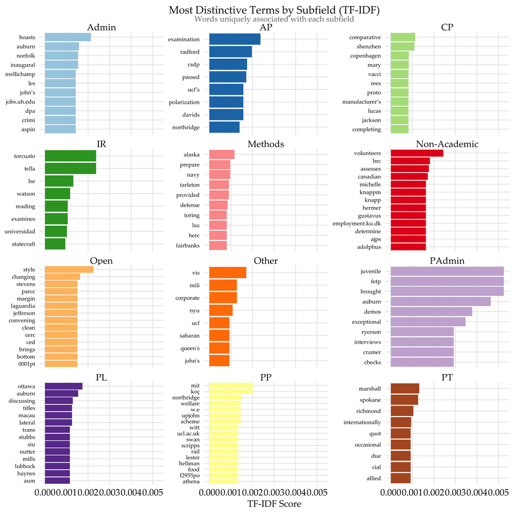

```r
tidy_words %>%
  filter(!is.na(subfield)) %>%
  count(subfield, word) %>%
  bind_tf_idf(word, subfield, n) %>%
  group_by(subfield) %>%
  slice_max(tf_idf, n = 8) %>% ungroup() %>%
  mutate(word = reorder_within(word, tf_idf, subfield)) %>%
  ggplot(aes(x = tf_idf, y = word, fill = subfield)) +
  geom_col(show.legend = FALSE) +
  facet_wrap(~ subfield, scales = "free_y", ncol = 3) +
  scale_y_reordered() +
  scale_fill_brewer(palette = "Paired") +
  labs(title    = "Most Distinctive Terms by Subfield (TF-IDF)",
       subtitle = "Words uniquely associated with each subfield",
       x = "TF-IDF Score", y = NULL) +
  theme(axis.text.y = element_text(size = 8, family = PAL))
```

## 6.3 TF-IDF: Distinctive Terms by Rank

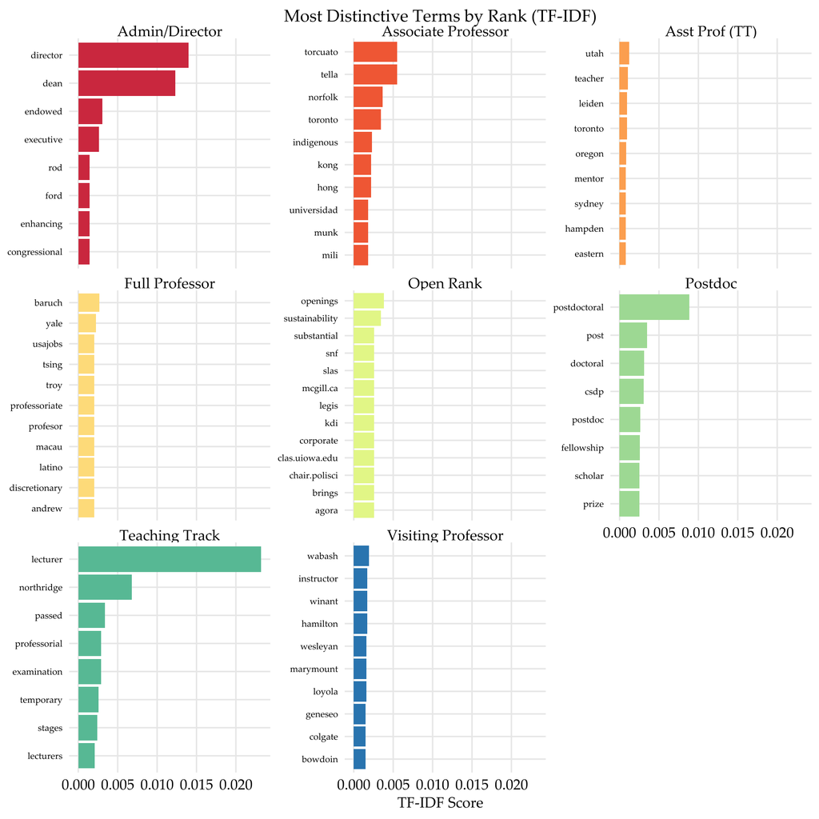

```r
tidy_words %>%
  filter(rank_category %in% tt_ranks) %>%
  count(rank_category, word) %>%
  bind_tf_idf(word, rank_category, n) %>%
  group_by(rank_category) %>%
  slice_max(tf_idf, n = 8) %>% ungroup() %>%
  mutate(word = reorder_within(word, tf_idf, rank_category)) %>%
  ggplot(aes(x = tf_idf, y = word, fill = rank_category)) +
  geom_col(show.legend = FALSE) +
  facet_wrap(~ rank_category, scales = "free_y", ncol = 3) +
  scale_y_reordered() +
  scale_fill_brewer(palette = "Spectral") +
  labs(title = "Most Distinctive Terms by Rank (TF-IDF)",
       x = "TF-IDF Score", y = NULL) +
  theme(axis.text.y = element_text(size = 8, family = PAL))
```

## 6.4 Top Bigrams

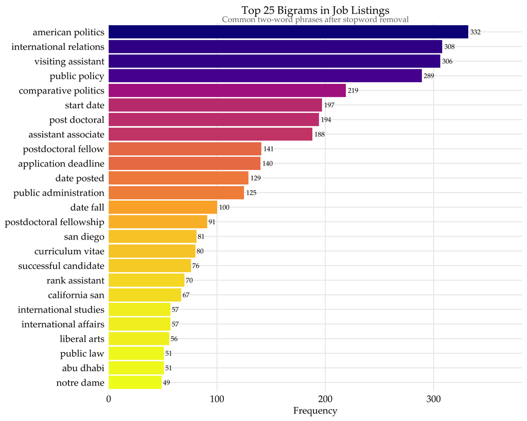

```r
jobs %>%
  unnest_tokens(bigram, full_text, token = "ngrams", n = 2) %>%
  separate(bigram, into = c("w1","w2"), sep = " ") %>%
  filter(!w1%in% stop_words$word, !w2%in% stop_words$word,
         !w1%in% ps_stopwords$word, !w2%in% ps_stopwords$word,
         str_length(w1) > 2, str_length(w2) > 2,
         !str_detect(w1,"^\\d+$"), !str_detect(w2,"^\\d+$")) %>%
  unite(bigram, w1, w2, sep = " ") %>%
  count(bigram, sort = TRUE) %>%
  slice_head(n = 25) %>%
  ggplot(aes(x = n, y = reorder(bigram, n), fill = n)) +
  geom_col(show.legend = FALSE) +
  geom_text(aes(label = comma(n)), hjust = -0.2,
            size = 3.3, family = PAL) +
  scale_fill_viridis_c(option = "C", direction = -1) +
  scale_x_continuous(labels = comma,
                     expand = expansion(mult = c(0, .15))) +
  labs(title    = "Top 25 Bigrams in Job Listings",
       subtitle = "Common two-word phrases after stopword removal",
       x = "Frequency", y = NULL)
```

## 6.5 Word Clouds by Subfield

**American Politics**

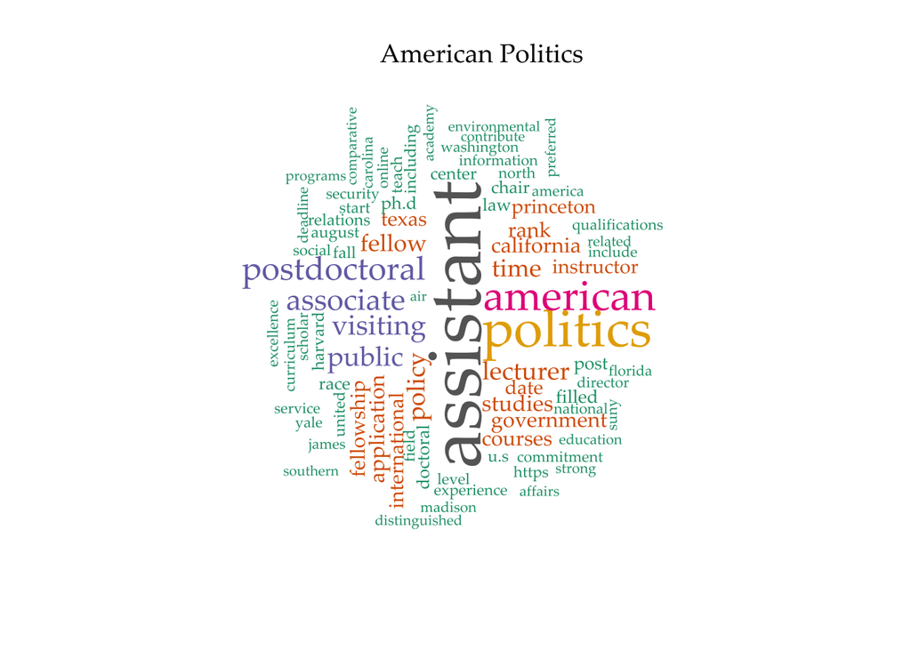

**Comparative Politics**

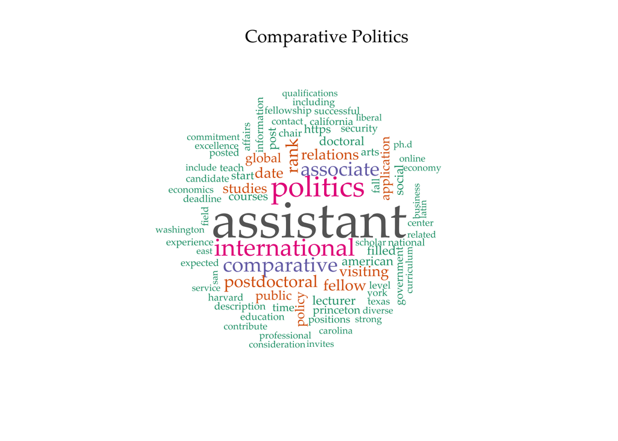

**International Relations**

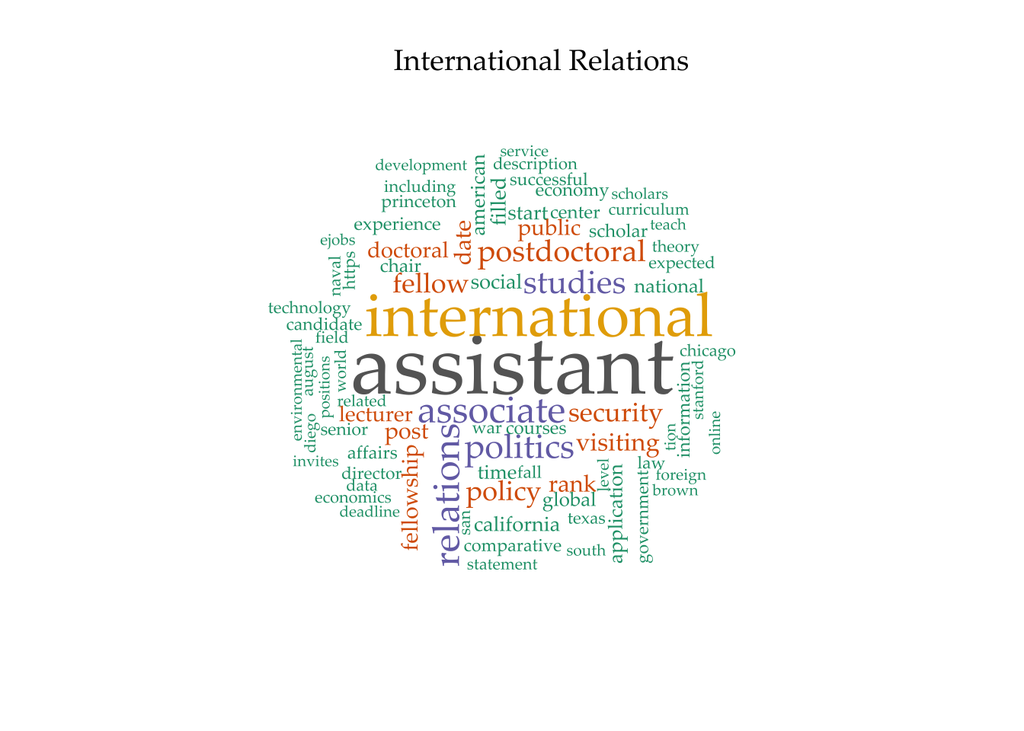

**Methodology**

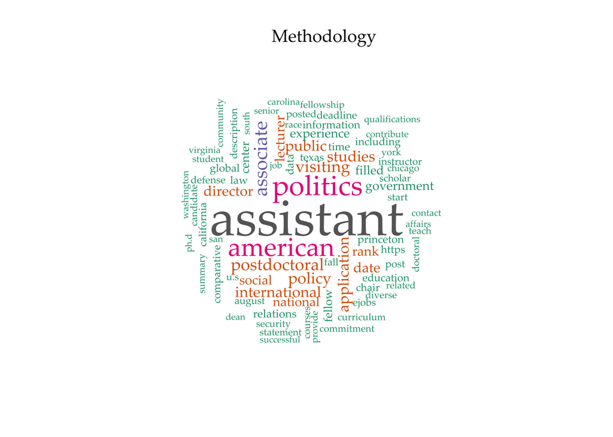

**Political Theory**

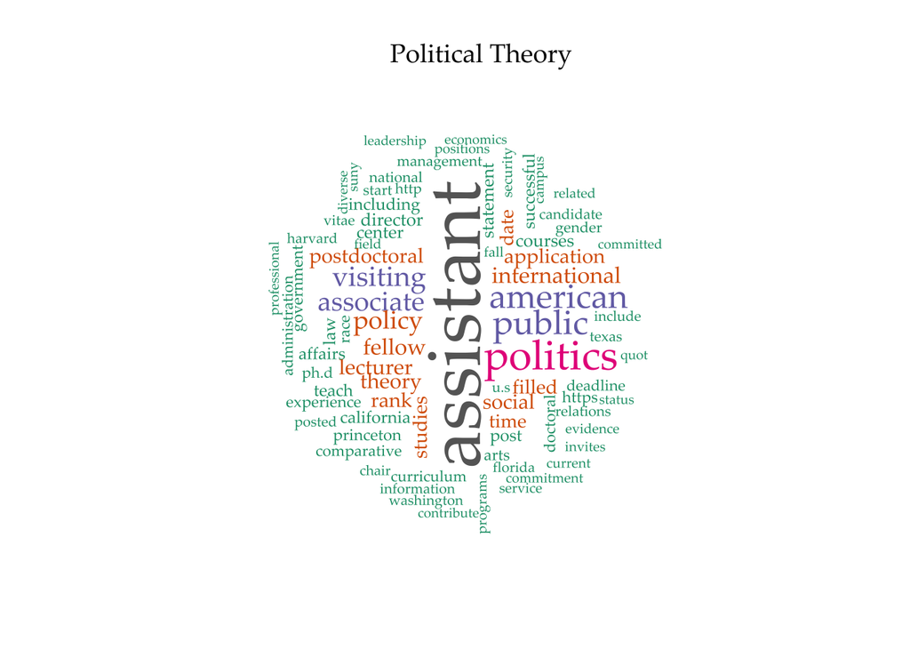

**Public Law**

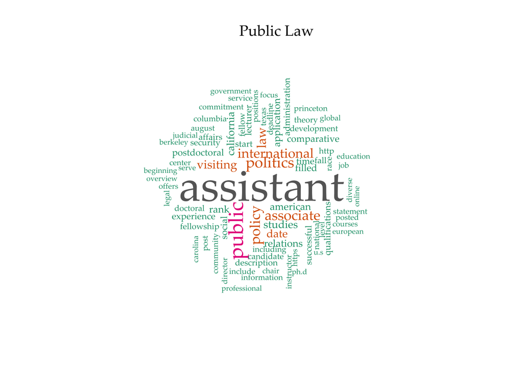

**Public Policy**

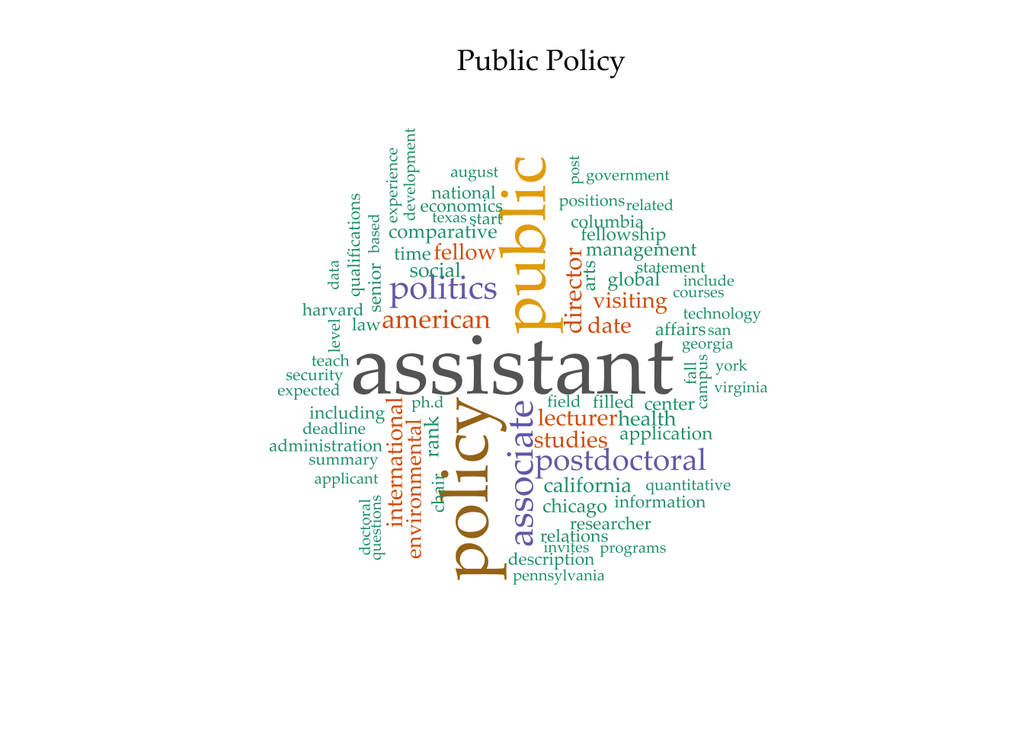

# 7 Browse All Jobs

| ejobs_id | year | subfield | org_name | rank | rank_category | unit | start_date | date_posted | deadline | salary | region | state_raw |
| --- | --- | --- | --- | --- | --- | --- | --- | --- | --- | --- | --- | --- |
| 16323 | 2026 | AP | University of Missouri, Columbia position is filled. | Hicks and Martha Griffiths Endowed Chair in American | Admin/Director |  | is flexible. Benefit Eligibility | 12/22/2025 |  |  | Midwest | Missouri |
| 16290 | 2026 | AP |  |  | Other/NEC | has been filled. Please direct inquiries to Didac Queralt, | 07/01/2026 | 12/12/2025 will be required to provide Official Transcripts of their highest-earned | Open until Filled will be subject to Criminal Background Check. The selected candidate | Competitive degree upon hire. | Non-US / Unknown |  |
| 16289 | 2026 | AP | University of North Carolina, Charlotte Application Deadline: Open until Filled | Knight Professorship of Public Policy | Other/NEC |  | Fall 2026 | 12/11/2025 | Open until Filled |  | South | North Carolina |
| 16284 | 2026 | AP |  |  | Other/NEC |  | Summer 2026 | 12/10/2025 but not limited to intro courses in both. | Open until Filled Syllabi for classes in American Politics and Political Theory, including | $60,000 - $69,999 | Non-US / Unknown |  |
| 16264 | 2026 | AP |  |  | Other/NEC |  | and documented success and experience teaching | 11/26/2025 holding a faculty position. Please apply on Interfolio at this link. | 1/15/2026 transcripts is also required for postdoctoral applicants not currently | $70,000 - $79,999 | Non-US / Unknown |  |
| 16270 | 2026 | AP | tics, Political Theory University College London |  | Other/NEC |  |  | 12/8/2025 |  |  | Non-US / Unknown |  |
| 16288 | 2026 | AP | University of Pennsylvania |  | Other/NEC |  | University of Pennsylvania | 12/11/2025 | 1/11/2026 | Negotiable | Northeast | Pennsylvania |
| 16320 | 2026 | AP |  |  | Other/NEC |  | Application Deadline: Open until Filled | 12/19/2025 University of Pennsylvania | Open until Filled | Competitive Rank: Postdoctoral Fellow | Non-US / Unknown |  |
| 16369 | 2026 | AP | Colorado State University as well as other needed upper division undergraduate courses in Ameri- | Visiting Assistant Professor can politics. | Visiting Professor |  | Fall 2026 | 1/22/2026 | Open until Filled |  | West | Colorado |
| 16331 | 2026 | AP |  |  | Other/NEC | graduates about 60 majors each year. More information University of North Florida | Fall 2026 | 1/5/2026 seeking a 9-month, tenure-earning, Assistant Professor of American | Open until Filled The Department of Political Science and Public Administration is | Competitive Politics and/or Public Administration/Public Policy. Position respon- | South | Florida |

[output cut: 10158 more lines]

# 8 Appendix

## 8.2 Data Pipeline Summary

| Stage | Tool | Output |
| --- | --- | --- |
| PDF text extraction | `pdftools::pdf_text()` | Raw character vectors |
| TOC count parsing | `stringr` regex on pages 1–3 | `ps_jobs_toc_counts.csv` |
| Body text scraping | Line-by-line section tracker + eJobs ID flush | `ps_jobs_all_raw.csv` |
| Deduplication | `dplyr::distinct(ejobs_id)` | `ps_jobs_all_unique.csv` |
| Verification | TOC count vs scraped count per issue × subfield | `ps_jobs_verification.csv` |
| Analytics & Report | `ggplot2`, `tidytext`, `maps`, Quarto | This document |

## 8.3 Subfield Code Reference

| Code | Full Name |
| --- | --- |
| AP | American Government and Politics |
| CP | Comparative Politics |
| IR | International Relations |
| Methods | Methodology |
| PT | Political Theory |
| PL | Public Law |
| PP | Public Policy |
| PAdmin | Public Administration |
| Admin | Administration |
| Non-Academic | Non-Academic Positions |
| Open | Open Subfield |
| Other | Other |